# Welcome to Matrix Lab

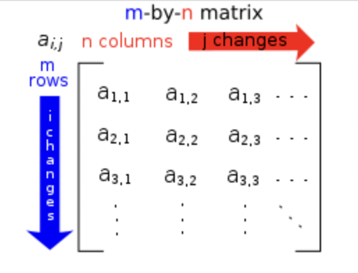

#### 1. A two-dimensional array consists of a collection of elements organized into rows and columns. Individual elements are referenced by specifying the specific row and column indices (r, c), both of which start at 0.

**Note: Implement the 2D array as an array of arrays**

**(Python, Java, C++): Implement a class Array2D that has the following methods**

- Array2D( nrows, ncols ): Creates a two-dimensional array organized into rows and columns. The nrows and ncols arguments indicate the size of the table. The individual elements of the table are initialized to None.
- numRows( ): Returns the number of rows in the 2-D array.
- numCols( ): Returns the number of columns in the 2-D array.
- clear( value ): Clears the array by setting each element to the given value.
- getitem( i1, i2 ): Returns the value stored in the 2-D array element at the position indicated by the 2-tuple (i1,i2), both of which must be within the valid range.
- setitem(i1, i2, value): Modifies the contents of the 2-D array element indicated by the 2-tuple (i1,i2) with the new value. Both indices must be within the valid range.

**(C Language) Implement the above as functions with the 2D array as the first argument in each case.**

- For example, numRows(my2darray), getitem(my2darray, i1, i2),..etc.

#### 2. A two-dimensional array consists of a collection of elements organized into rows and columns. Individual elements are referenced by specifying the specific row and column indices (r, c), both of which start at 0.

**Note: Implement the 2D array as an array of linked lists (discussed in class) -- sparse matrix version**

**(Python, Java, C++): Implement a class Array2D that has the following methods**

- Array2D( nrows, ncols ): Creates a two-dimensional array organized into rows and columns. The nrows and ncols arguments indicate the size of the table. The individual elements of the table are initialized to None.
- numRows( ): Returns the number of rows in the 2-D array.
- numCols( ): Returns the number of columns in the 2-D array.
- clear( value ): Clears the array by setting each element to the given value.
- getitem( i1, i2 ): Returns the value stored in the 2-D array element at the position indicated by the 2-tuple (i1,i2), both of which must be within the valid range.
- setitem(i1, i2, value): Modifies the contents of the 2-D array element indicated by the 2-tuple (i1,i2) with the new value. Both indices must be within the valid range.

**(C Language) Implement the above as functions with the 2D array as the first argument in each case.**

- For example, numRows(my2darray), getitem(my2darray, i1, i2),..etc.

#### 3. A matrix is a collection of scalar values arranged in rows and columns as a rectangular grid of a fixed size. The elements of the matrix can be accessed by specifying a given row and column index with indices starting at 0.

**Note: Implement the 2D array as an array of linked lists (discussed in class) -- sparse matrix version**

**(Python, Java, C++): Implement a class Matrix that has the following methods**

- Matrix( rows, ncols ): Creates a new matrix containing nrows and ncols with each element initialized to 0.
- numRows( ): Returns the number of rows in the matrix.
- numCols( ): Returns the number of columns in the matrix.
- getitem ( row, col ): Returns the value stored in the given matrix element. Both row and col must be within the valid range.
- setitem ( row, col, scalar ): Sets the matrix element at the given row and col to scalar. The element indices must be within the valid range.
- scaleBy( scalar ): Multiplies each element of the matrix by the given scalar value. The matrix is modified by this operation.
- transpose( ): Returns a new matrix that is the transpose of this matrix.
- add ( rhsMatrix ): Creates and returns a new matrix that is the result of adding this matrix to the given rhsMatrix. The size of the two matrices must be the same.
- subtract ( rhsMatrix ): The same as the add() operation but subtracts the two matrices.
- multiply ( rhsMatrix ): Creates and returns a new matrix that is the result of multiplying this matrix to the given rhsMatrix. The two matrices must be of appropriate sizes as defined for matrix multiplication.

**(C Language) Implement the above as functions with the matrix as the first argument in each case.**

- For example, transpose(mymatrix), subtract(mymatrix, rhsmatrix),..etc.

#### 4. (Game of Life) A life grid is used to represent and store the area in the game of Life that contains organisms. The grid contains a rectangular grouping of cells of a finite size divided into rows and columns. The individual cells, which can be alive or dead, are referenced by row and column indices, both of which start at zero.

**(Python, Java, C++): Implement a class LifeGrid that has the following methods**

- LifeGrid( nrows, ncols ): Creates a new game grid consisting of nrows and ncols. All cells in the grid are set to dead.
- numRows( ): Returns the number rows in the grid.
- numCols( ): Returns the number of columns in the grid.
- configure(coordList): Configures the grid for evolving the next generation. The coordList argument is a sequence of 2-tuples with each tuple representing the coordinates (r, c) of the cells to be set as alive. All remaining cells are cleared or set to dead.
- clearCell( row, col ): Clears the individual cell (row, col) and sets it to dead. The cell indices must be within the valid range of the grid.
- setCell( row, col ): Sets the indicated cell (row, col) to be alive. The cell indices must be within the valid range of the grid.
- isLiveCell( row,col ): Returns a boolean value indicating if the given cell (row, col) contains a live organism. The cell indices must be within the valid range of the grid.
- numLiveNeighbors( row, col ): Returns the number of live neighbors for the given cell (row, col). The neighbors of a cell include all of the cells immediately surrounding it in all directions. For the cells along the border of the grid, the neighbors that fall outside the grid are assumed to be dead. The cell indices must be within the valid range of the grid.

**(C Language) Implement the above as functions with the LifeGrid as the first argument in each case.**

- For example, isLiveCell(mylifegrid, row, col),..etc.